# Cyclistic Bike Share Case Study

## Introduction

This is the Cyclistic bike-share analysis case study that is assigned as part of the Google Data Analytics Professional Certificate course from Coursera.

The goal of this case study is to use the data analysis process which includes ask, prepare, process, analyze, share, and act on a real life business problem.

## Scenario

We are a junior data analyst working at a fictional bike-share company in Chicago named Cyclistic. We believe that maximizing the number of annual memberships will help the company succeed. Our goal is to understand how casual and annual members use our bikes differently and design a strategy to convert casual riders into annual members based on these insights.

## Data Context

We acquire our monthly data for the year 2022 from this link: [Click here to see divvy-tripdata](https://divvy-tripdata.s3.amazonaws.com/index.html)

The data is made available by Motivate International Inc. under this [license](https://ride.divvybikes.com/data-license-agreement).

Coincidentally, this is an interesting dataset for me to work with as I currently reside in Chicago and I see these divvy bikes quite often.

# ASK

### What problem am I solving?

The director wants to maximize the number of annual memberships. Therefore we need to find the difference between casual riders and annual members and design a strategy to convert casuals into annuals. Our recommendations must be backed with compelling data insights and data visualizations.

# PREPARE

### Where is our data located? How is it organized? Are we allowed to use this data?

Our data is made available through monthly csv files and we have a license to use it.

# PROCESS

## Data Importing

Load in libraries

```r
library(tidyverse)
```

```r
library(dplyr)
library(dplyr)
library(corrplot)
library(anytime)
library(lubridate)
library(scales)
library(ggplot2)
library(reshape2)
library(stats)
library(fastDummies)
```

Grab all csv files in our working directory and create a list that stores each individual csv file as a dataframe as a list element.

```r
csv_files <- list.files(pattern = ".csv", full.names = TRUE)
data_list <- lapply(csv_files, read.csv)
```

Check if all the csv files have the same columns in the same order

```r
same_cols <- sapply(data_list, function(x) identical(names(x), names(data_list[[1]])))

if (all(same_cols)) {
  cat("All CSV files have the same columns in the same order.\n")
} else {
  cat("Not all CSV files have the same columns in the same order.\n")
}
```

```
## All CSV files have the same columns in the same order.
```

Check if all csv files have the same number of columns

```r
same_ncols <- sapply(data_list, function(x) ncol(x) == ncol(data_list[[1]]))

if (all(same_ncols)) {
  cat("All CSV files have the same number of columns.\n")
} else {
  cat("Not all CSV files have the same number of columns.\n")
}
```

```
## All CSV files have the same number of columns.
```

Check if all columns have the same data types in all csv files

```r
col_classes <- lapply(data_list, function(x) sapply(x, class))

all_col_classes_same <- all(sapply(col_classes, function(x) all(x == col_classes[[1]])))

if (all_col_classes_same) {
  cat("All data frames have matching column data types.\n")
} else {
  cat("Not all data frames have matching column data types.\n")
}
```

```
## All data frames have matching column data types.
```

```r
combined_data <- do.call(rbind,data_list)

head(combined_data)
```

[output not shown]

## Data Cleaning

Create a backup before any changes

```r
combined_data_preclean = combined_data
```

Check the structure of the dataframe and the datatypes of each column

```r
str(combined_data)
```

[output not shown]

Explore each column to see which needs cleaning. Check if there are any duplicates. Returns 0 if there are no duplicates - there are no duplicates.

```r
anyDuplicated(combined_data)
```

```
## [1] 0
```

Checking if ride_id is unique, it should since technically each ride is distinct. No results, all ride ids are unique.

```r
anyDuplicated(combined_data$ride_id)
```

```
## [1] 0
```

```r
unique(combined_data$rideable_type)
```

```
## [1] "electric_bike" "classic_bike"  "docked_bike"
```

Explore the first couple of rows we have for this date column.

```r
head(combined_data$started_at[!is.na(combined_data$started_at)])
```

```
## [1] "2022-01-13 11:59:00" "2022-01-10 08:41:00" "2022-01-25 04:53:00"
## [4] "2022-01-04 00:18:00" "2022-01-20 01:31:00" "2022-01-11 18:48:00"
```

It is possible that there could be multiple date formats. Check by subsetting the dataset to filter out NAs and the first format we saw through grepl and regular expression.

```r
head(combined_data$started_at[!is.na(combined_data$started_at) & !grepl("^\\d{4}-\\d{2}-\\d{2} \\d{2}:\\d{2}:\\d{2}$", combined_data$started_at)])
```

```
## character(0)
```

```r
head(combined_data$started_at[!is.na(combined_data$started_at) & !grepl("^\\d{4}-\\d{2}-\\d{2} \\d{2}:\\d{2}:\\d{2}$", combined_data$started_at)
                         & !grepl("^\\d{1,2}/\\d{1,2}/\\d{4} \\d{1,2}:\\d{2}$", combined_data$started_at)])
```

```
## character(0)
```

It is a possibility that the other date column has other date formats, perform the same check.

```r
head(combined_data$ended_at[!is.na(combined_data$ended_at) & !grepl("^\\d{4}-\\d{2}-\\d{2} \\d{2}:\\d{2}:\\d{2}$", combined_data$ended_at)
                         & !grepl("^\\d{1,2}/\\d{1,2}/\\d{4} \\d{1,2}:\\d{2}$", combined_data$ended_at)])
```

```
## character(0)
```

For both date columns, we will use the parse_date_time function from the lubridate library in order to convert the two formats into type POSIXct date-time. Then we will use format to specify the date format that we want and convert it back to date-time with POSIXct since format returns a chr type. I chose to keep the format with only minutes to keep it more consistent otherwise a lot of our times will just end in 00 seconds.

```r
combined_data$started_at = parse_date_time(combined_data$started_at, c("%m/%d/%Y %H:%M", "%Y-%m-%d %H:%M:%S"))
combined_data$started_at = format(combined_data$started_at, "%m/%d/%Y %H:%M")
combined_data$ended_at = parse_date_time(combined_data$ended_at, c("%m/%d/%Y %H:%M", "%Y-%m-%d %H:%M:%S"))
combined_data$ended_at = format(combined_data$ended_at, "%m/%d/%Y %H:%M")
combined_data$started_at = as.POSIXct(combined_data$started_at, format = "%m/%d/%Y %H:%M")
combined_data$ended_at = as.POSIXct(combined_data$ended_at, format = "%m/%d/%Y %H:%M")
```

Create a column to calculate the time difference between trips. Create a df to only see the time columns and explore it. Filter it so I can take a look at trips are considered bad trips if they are less than a minute or over 864000 seconds.

```r
combined_data$time_diff_sec = as.numeric(difftime(combined_data$ended_at, combined_data$started_at, units = "secs"))
df_timecheck = combined_data %>% select(started_at, ended_at, time_diff_sec) %>% arrange(time_diff_sec)
df_timecheck_badtrips = df_timecheck %>% filter(time_diff_sec < 60 | time_diff_sec > 864000) %>% arrange(time_diff_sec)
head(df_timecheck_badtrips)
```

[output not shown]

```r
combined_data <- combined_data %>%
  mutate(
    temp = started_at, #Need to create a temp for ended_at to reference otherwise it will reference the same value since started_at will be changed to ended_at
    started_at = if_else(time_diff_sec < 0, ended_at, started_at),
    ended_at = if_else(time_diff_sec < 0, temp, ended_at)
  ) %>% select(-temp)
combined_data$time_diff_sec = as.numeric(difftime(combined_data$ended_at, combined_data$started_at, units = "secs"))
combined_data = combined_data %>% filter(time_diff_sec >= 60 & time_diff_sec <= 864000)
min(combined_data$time_diff_sec)
```

```
## [1] 60
```

```r
max(combined_data$time_diff_sec)
```

```
## [1] 863880
```

Double check if all trips are in 2022. All of them start in 2022 but some end in 2023 which is fine.

```r
min(combined_data$started_at)
```

```
## [1] "2022-01-01 CST"
```

```r
max(combined_data$started_at)
```

```
## [1] "2022-12-31 23:59:00 CST"
```

```r
min(combined_data$ended_at)
```

```
## [1] "2022-01-01 00:01:00 CST"
```

```r
max(combined_data$ended_at)
```

```
## [1] "2023-01-02 04:56:00 CST"
```

Extract months, days, and hours from our date column.

```r
combined_data$start_month = format(combined_data$started_at, "%m")
combined_data$start_day = format(combined_data$started_at, "%A")
combined_data$start_hour = format(combined_data$started_at, "%H")

head(combined_data %>% select(started_at, start_month, start_day, start_hour))
```

```
##            started_at start_month start_day start_hour
## 1 2022-01-13 11:59:00          01  Thursday         11
## 2 2022-01-10 08:41:00          01    Monday         08
## 3 2022-01-25 04:53:00          01   Tuesday         04
## 4 2022-01-04 00:18:00          01   Tuesday         00
## 5 2022-01-20 01:31:00          01  Thursday         01
## 6 2022-01-11 18:48:00          01   Tuesday         18
```

Check our station name and id columns for cleaning. Many rows have blanks, there are different ids/names for the same station, ids end in .0, some have ‘test’,‘charging’,‘divvy 001’ and ‘divvy cassette’ in their names and ids.

```r
df_startstations = combined_data %>% select(start_station_name, start_station_id) %>% distinct(start_station_name, start_station_id) %>% arrange(start_station_id)
df_endstations = combined_data %>% select(end_station_name, end_station_id) %>% distinct (end_station_name, end_station_id) %>% arrange(end_station_id)

head(df_startstations)
```

```
##                               start_station_name start_station_id
## 1
## 2                                 MTV Hubbard St           021320
## 3 Public Rack - Fullerton Ave & Narragansett Ave             1011
## 4            Public Rack - Langley Ave & 49th St             1012
## 5             Public Rack - Pulaski Rd & Lake St             1013
## 6      Public Rack - Richmond St & Thorndale Ave             1014
```

```r
head(df_endstations)
```

```
##                                 end_station_name end_station_id
## 1
## 2                                 MTV Hubbard St         021320
## 3 Public Rack - Fullerton Ave & Narragansett Ave           1011
## 4            Public Rack - Langley Ave & 49th St           1012
## 5             Public Rack - Pulaski Rd & Lake St           1013
## 6      Public Rack - Richmond St & Thorndale Ave           1014
```

Delete rows that fit our criteria.

```r
combined_data = combined_data %>% filter(!grepl('test|charging|divvy cassette|divvy 001', tolower(start_station_name)) &
                           !grepl('test|charging|divvy cassette|divvy 001', tolower(start_station_id))) %>%
  filter(!grepl('test|charging|divvy cassette|divvy 001', tolower(end_station_name)) &
           !grepl('test|charging|divvy cassette|divvy 001', tolower(end_station_id)))
```

Replace names and ids ending in .0 with empty strings.

```r
combined_data = combined_data %>% mutate(
  start_station_name = gsub("\\.0$", "", start_station_name),
  start_station_id = gsub("\\.0$", "", start_station_id),
  end_station_name = gsub("\\.0$", "", end_station_name),
  end_station_id = gsub("\\.0$", "", end_station_id)
)
```

# ANALYZE AND SHARE

Return a count of trips made by casuals and members

```r
gb_mc = combined_data %>% group_by(member_casual) %>% summarise(count = n())
gb_mc
```

```
## # A tibble: 2 × 2
##   member_casual   count
##   <chr>           <int>
## 1 casual        2261402
## 2 member        3256424
```

Return a count of trips made by casuals and members on different bikes. Quick viz for better clarity.

```r
gb_mc_rt = combined_data %>% group_by(member_casual, rideable_type) %>% summarise(count = n())
gb_mc_rt
```

```
## # A tibble: 5 × 3
## # Groups:   member_casual [2]
##   member_casual rideable_type   count
##   <chr>         <chr>           <int>
## 1 casual        classic_bike   867423
## 2 casual        docked_bike    175639
## 3 casual        electric_bike 1218340
## 4 member        classic_bike  1665135
## 5 member        electric_bike 1591289
```

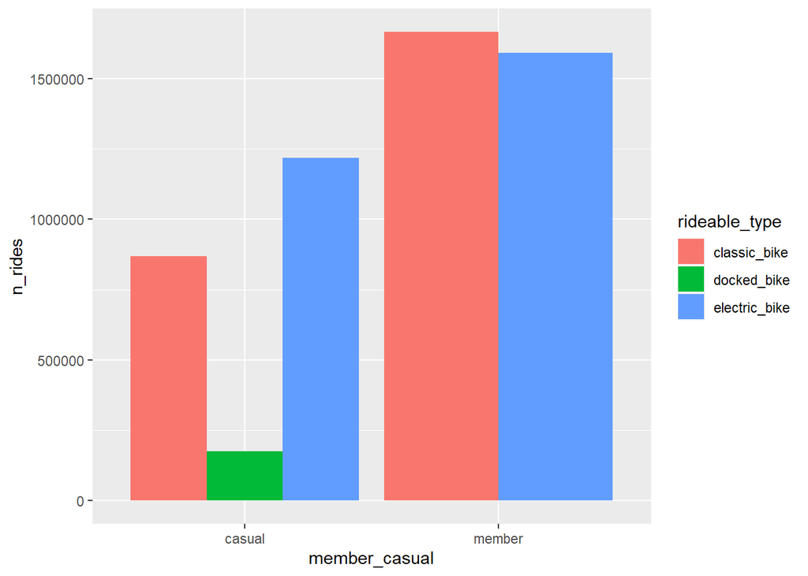

```r
mc_rtplot = combined_data %>% group_by(member_casual, rideable_type) %>% summarise(n_rides = n()) %>%
  ggplot(aes(x = member_casual, y = n_rides, fill = rideable_type)) +
  geom_col(position = "dodge")
mc_rtplot
```

Create a plot to visualize the average trip duration between members and casuals

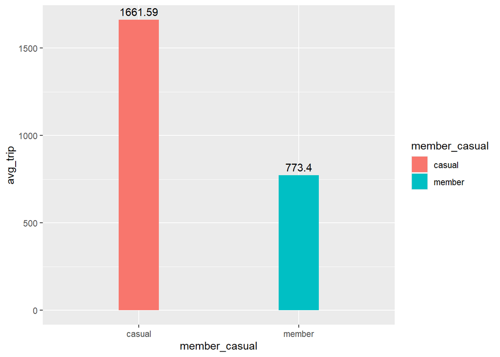

```r
avgtrip_plot = combined_data %>% group_by(member_casual) %>% summarise(avg_trip = mean(time_diff_sec)) %>%
  ggplot(aes(x = member_casual,y = avg_trip, fill = member_casual)) +
  geom_bar(stat = "identity", width = 0.25) +
  geom_text(aes(label = round(avg_trip,2), vjust = -0.5))
avgtrip_plot
```

Visualize it again except docked_bike bike type is removed.

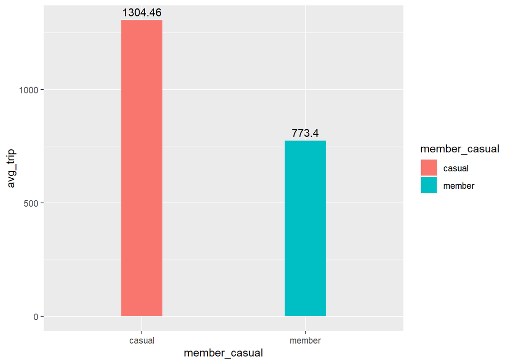

```r
avgtrip_plot2 = combined_data %>% filter(rideable_type != "docked_bike") %>% group_by(member_casual) %>% summarise(avg_trip = mean(time_diff_sec)) %>%
  ggplot(aes(x = member_casual,y = avg_trip, fill = member_casual)) +
  geom_bar(stat = "identity", width = 0.25) +
  geom_text(aes(label = round(avg_trip,2), vjust = -0.5))
avgtrip_plot2
```

Visualize the number of trips taken per month between members and casuals

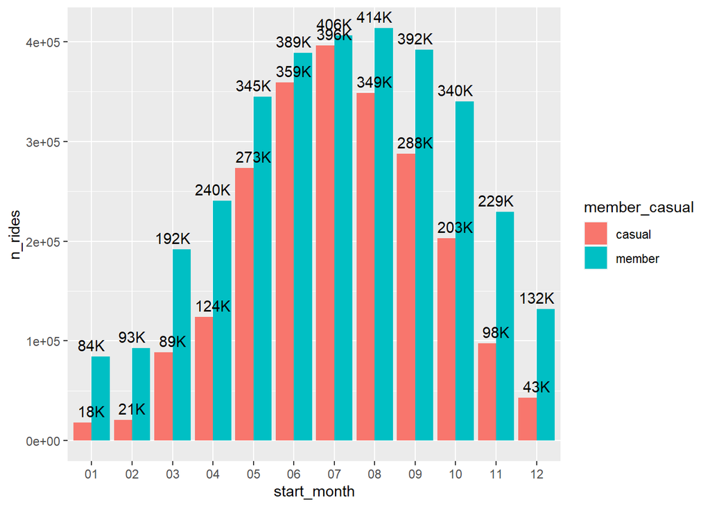

```r
monthtrip_plot = combined_data %>% group_by(member_casual, start_month) %>% summarise(n_rides = n()) %>%
  ggplot(aes(x = start_month, y = n_rides, fill = member_casual)) +
  geom_col(position = "dodge") +
  geom_text(aes(label = sprintf("%sK", comma(round(n_rides/1000))), vjust = -0.5))
monthtrip_plot
```

Visualize the number of trips taken per weekday between members and casuals

[figure not shown]

```r
weekday_names <- c("Monday", "Tuesday", "Wednesday", "Thursday", "Friday", "Saturday", "Sunday")
daytrip_plot = combined_data %>% group_by(member_casual, start_day) %>% summarise(n_rides = n()) %>%
  ggplot(aes(x = start_day, y = n_rides, fill = member_casual)) +
  geom_col(position = "dodge") +
  geom_text(aes(label = sprintf("%sK", comma(round(n_rides/1000))), vjust = -0.5)) +
  scale_x_discrete(labels = weekday_names)
daytrip_plot
```

Visualize the number of trips taken per hour between members and casuals

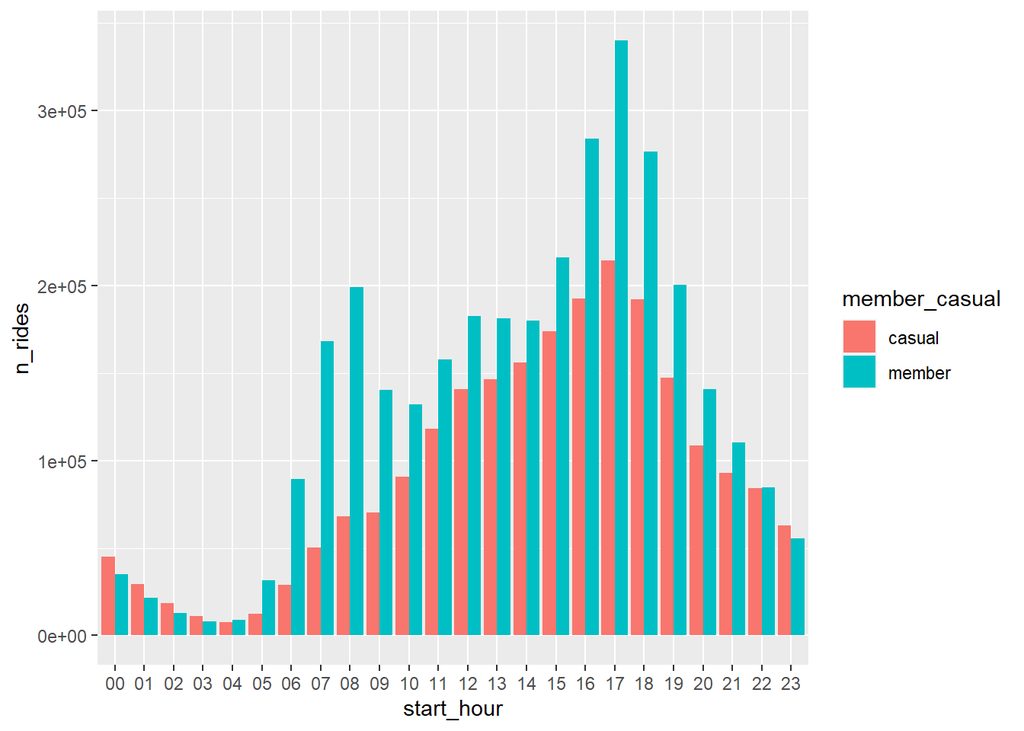

```r
hourtrip_plot = combined_data %>% group_by(member_casual, start_hour) %>% summarise(n_rides = n()) %>%
  ggplot(aes(x = start_hour, y = n_rides, fill = member_casual)) +
  geom_col(position = "dodge")
hourtrip_plot
```

Taking a look at the most popular start and end stations

```r
gb_mc_startstation = combined_data %>% group_by(member_casual, start_station_name) %>% summarise(n_rides = n()) %>% arrange(desc(n_rides))
head(gb_mc_startstation)
```

```
## # A tibble: 6 × 3
## # Groups:   member_casual [2]
##   member_casual start_station_name                  n_rides
##   <chr>         <chr>                                 <int>
## 1 member        ""                                   474769
## 2 casual        ""                                   337211
## 3 casual        "Streeter Dr & Grand Ave"             57416
## 4 casual        "DuSable Lake Shore Dr & Monroe St"   31531
## 5 casual        "Millennium Park"                     25202
## 6 casual        "Michigan Ave & Oak St"               24941
```

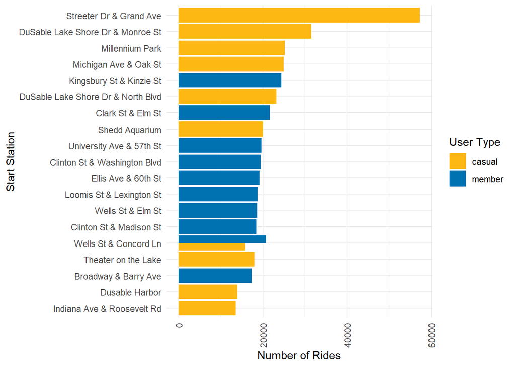

```r
startstation_plot <- combined_data %>%
  filter(!is.na(start_station_name) & !is.na(member_casual) & start_station_name != "" & member_casual != "") %>%
  group_by(member_casual, start_station_name) %>%
  summarise(n_rides = n()) %>%
  arrange(desc(n_rides)) %>%
  mutate(rank = dense_rank(desc(n_rides))) %>% # add a rank column
  filter(rank <= 10) %>% # filter for the top 10 stations
  ggplot(aes(x = reorder(start_station_name, n_rides), y = n_rides, fill = member_casual)) +
  geom_col(position = "dodge") +
  labs(x = "Start Station", y = "Number of Rides", fill = "User Type") +
  scale_fill_manual(values = c("#FDB813", "#0072B2")) + # set custom colors
  theme_minimal() + # apply a minimal theme
  theme(axis.text.x = element_text(angle = 90, vjust = 0.5, hjust=1)) +# rotate x-axis labels
  coord_flip()
startstation_plot
```

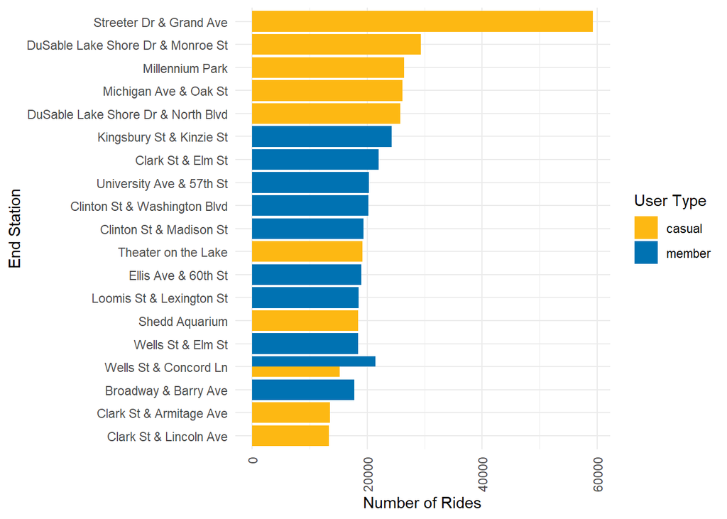

```r
endstation_plot <- combined_data %>%
  filter(!is.na(end_station_name) & !is.na(member_casual) & end_station_name != "" & member_casual != "") %>%
  group_by(member_casual, end_station_name) %>%
  summarise(n_rides = n()) %>%
  arrange(desc(n_rides)) %>%
  mutate(rank = dense_rank(desc(n_rides))) %>% # add a rank column
  filter(rank <= 10) %>% # filter for the top 10 stations
  ggplot(aes(x = reorder(end_station_name, n_rides), y = n_rides, fill = member_casual)) +
  geom_col(position = "dodge") +
  labs(x = "End Station", y = "Number of Rides", fill = "User Type") +
  scale_fill_manual(values = c("#FDB813", "#0072B2")) + # set custom colors
  theme_minimal() + # apply a minimal theme
  theme(axis.text.x = element_text(angle = 90, vjust = 0.5, hjust=1)) +# rotate x-axis labels
  coord_flip()
endstation_plot
```

# MAIN TAKEAWAYS AND RECOMMENDATIONS

Casuals take longer trips than Members; increase the amount Casuals have to pay the longer they ride.

Trips by Casuals are most popular during the summer season along the coast of Lake Michigan on weekends and the afternoons; Create a campaign that uses these times and locations.

## Other Statistical Analyses

T-Test to determine whether or not there is a significant difference between the two means

```r
t.test(time_diff_sec ~ member_casual, data = combined_data)
```

```
##
##  Welch Two Sample t-test
##
## data:  time_diff_sec by member_casual
## t = 118.85, df = 2340964, p-value < 2.2e-16
## alternative hypothesis: true difference in means between group casual and group member is not equal to 0
## 95 percent confidence interval:
##  873.5428 902.8363
## sample estimates:
## mean in group casual mean in group member
##            1661.5894             773.3999
```

ANOVA test to determine if there is a statistical significant difference in means for more than 2 groups

```r
aov_model = aov(time_diff_sec ~ rideable_type, data = combined_data)
aov_model
```

```
## Call:
##    aov(formula = time_diff_sec ~ rideable_type, data = combined_data)
##
## Terms:
##                 rideable_type    Residuals
## Sum of Squares   4.263142e+12 2.876649e+14
## Deg. of Freedom             2      5517823
##
## Residual standard error: 7220.372
## Estimated effects may be unbalanced
```

```r
summary(aov_model)
```

```
##                    Df    Sum Sq   Mean Sq F value Pr(>F)
## rideable_type       2 4.263e+12 2.132e+12   40887 <2e-16 ***
## Residuals     5517823 2.877e+14 5.213e+07
## ---
## Signif. codes:  0 '***' 0.001 '**' 0.01 '*' 0.05 '.' 0.1 ' ' 1
```

Create a dataframe suitable for classification log model. We select all the columns that we want and create dummy columns for our categorical variables and deleting a column for each group of dummy variables to prevent the dummy variable trap.

```r
df_glm = combined_data %>% select(rideable_type, member_casual, time_diff_sec, start_month, start_day, start_hour) %>%
  dummy_cols(select_columns = c("member_casual","rideable_type","start_month","start_day","start_hour"), remove_first_dummy = FALSE, remove_selected_columns = TRUE) %>%
  select(-c("member_casual_member","rideable_type_docked_bike","start_month_01","start_day_Monday","start_hour_00"))
```

Perform a logistic regression model with our dependent variable being whether or not they are a casual or member.

```r
glm_model <- glm(member_casual_casual ~ ., data = df_glm, family = "binomial")
summary(glm_model)
```

```
##
## Call:
## glm(formula = member_casual_casual ~ ., family = "binomial",
##     data = df_glm)
##
## Deviance Residuals:
##     Min       1Q   Median       3Q      Max
## -8.4904  -0.9696  -0.6946   1.1868   2.4295
##
## Coefficients:
##                               Estimate Std. Error  z value Pr(>|z|)
## (Intercept)                  1.503e+01  5.290e+00    2.841 0.004496 **
## time_diff_sec                3.086e-04  1.058e-06  291.794  < 2e-16 ***
## rideable_type_classic_bike  -1.671e+01  5.290e+00   -3.158 0.001588 **
## rideable_type_electric_bike -1.622e+01  5.290e+00   -3.066 0.002168 **
## start_month_02               4.282e-02  1.176e-02    3.642 0.000270 ***
## start_month_03               6.855e-01  9.608e-03   71.343  < 2e-16 ***
## start_month_04               7.340e-01  9.353e-03   78.473  < 2e-16 ***
## start_month_05               1.157e+00  9.002e-03  128.525  < 2e-16 ***
## start_month_06               1.346e+00  8.923e-03  150.844  < 2e-16 ***
## start_month_07               1.331e+00  8.896e-03  149.564  < 2e-16 ***
## start_month_08               1.257e+00  8.914e-03  140.954  < 2e-16 ***
## start_month_09               1.121e+00  8.958e-03  125.147  < 2e-16 ***
## start_month_10               8.797e-01  9.070e-03   96.996  < 2e-16 ***
## start_month_11               6.924e-01  9.465e-03   73.156  < 2e-16 ***
## start_month_12               4.203e-01  1.034e-02   40.659  < 2e-16 ***
## start_day_Friday             1.472e-01  3.560e-03   41.350  < 2e-16 ***
## start_day_Saturday           4.577e-01  3.453e-03  132.553  < 2e-16 ***
## start_day_Sunday             3.859e-01  3.589e-03  107.514  < 2e-16 ***
## start_day_Thursday          -3.623e-04  3.553e-03   -0.102 0.918783
## start_day_Tuesday           -1.049e-01  3.649e-03  -28.754  < 2e-16 ***
## start_day_Wednesday         -9.061e-02  3.621e-03  -25.023  < 2e-16 ***
## start_hour_01                3.168e-02  1.197e-02    2.648 0.008109 **
## start_hour_02                8.450e-02  1.421e-02    5.948 2.71e-09 ***
## start_hour_03                6.364e-02  1.714e-02    3.712 0.000205 ***
## start_hour_04               -3.068e-01  1.816e-02  -16.894  < 2e-16 ***
## start_hour_05               -9.300e-01  1.345e-02  -69.139  < 2e-16 ***
## start_hour_06               -1.070e+00  1.028e-02 -104.141  < 2e-16 ***
## start_hour_07               -1.134e+00  9.161e-03 -123.793  < 2e-16 ***
## start_hour_08               -1.028e+00  8.800e-03 -116.787  < 2e-16 ***
```

[output cut: 10 more lines]

```
## start_hour_19               -4.184e-01  8.294e-03  -50.446  < 2e-16 ***
## start_hour_20               -3.915e-01  8.590e-03  -45.573  < 2e-16 ***
## start_hour_21               -2.994e-01  8.807e-03  -33.989  < 2e-16 ***
## start_hour_22               -1.504e-01  9.040e-03  -16.642  < 2e-16 ***
## start_hour_23               -5.847e-02  9.643e-03   -6.063 1.33e-09 ***
## ---
## Signif. codes:  0 '***' 0.001 '**' 0.01 '*' 0.05 '.' 0.1 ' ' 1
##
## (Dispersion parameter for binomial family taken to be 1)
##
##     Null deviance: 7468915  on 5517825  degrees of freedom
## Residual deviance: 6667970  on 5517782  degrees of freedom
## AIC: 6668058
##
## Number of Fisher Scoring iterations: 15
```

Explore the top variables based on the absolute value of their coefficient estimates of the glm model

```r
coefs = coef(glm_model)
abs_coefs = abs(coefs)
sorted_abscoefs = sort(abs_coefs, decreasing = TRUE)
top_vars <- data.frame(variable = names(coefs), coefficient = coefs, abs_coefficient = abs_coefs)
top_vars <- top_vars[order(-top_vars$abs_coefficient),][1:10,]
top_vars
```

```
##                                                variable coefficient
## rideable_type_classic_bike   rideable_type_classic_bike  -16.706464
## rideable_type_electric_bike rideable_type_electric_bike  -16.220474
## (Intercept)                                 (Intercept)   15.029485
## start_month_06                           start_month_06    1.346019
## start_month_07                           start_month_07    1.330591
## start_month_08                           start_month_08    1.256510
## start_month_05                           start_month_05    1.156926
## start_hour_07                             start_hour_07   -1.134123
## start_month_09                           start_month_09    1.121110
## start_hour_06                             start_hour_06   -1.070195
##                             abs_coefficient
## rideable_type_classic_bike        16.706464
## rideable_type_electric_bike       16.220474
## (Intercept)                       15.029485
## start_month_06                     1.346019
## start_month_07                     1.330591
## start_month_08                     1.256510
## start_month_05                     1.156926
## start_hour_07                      1.134123
## start_month_09                     1.121110
## start_hour_06                      1.070195
```

Correlation test to identify pairs w/ strong relations

```r
cor_df_glm = cor(df_glm)
cor_df_glm
```

[output not shown]

[output cut: 710 more lines]

```
## start_hour_09               -0.0294546506
## start_hour_10               -0.0303413688
## start_hour_11               -0.0339484421
## start_hour_12               -0.0368908819
## start_hour_13               -0.0371679542
## start_hour_14               -0.0376633828
## start_hour_15               -0.0407789665
## start_hour_16               -0.0454933934
## start_hour_17               -0.0494337871
## start_hour_18               -0.0450872841
## start_hour_19               -0.0383549374
## start_hour_20               -0.0321956402
## start_hour_21               -0.0289480072
## start_hour_22               -0.0262674030
## start_hour_23                1.0000000000
```

Create a heatmap of our correlation dataframe. Not too useful since we’re mainly using time variables.

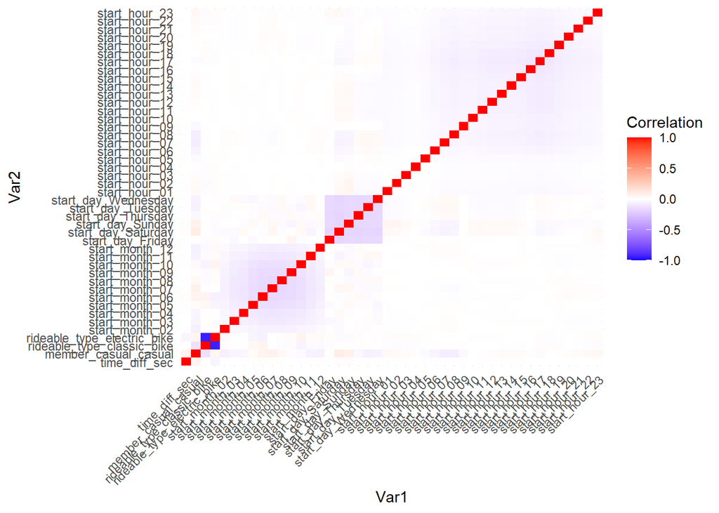

```r
cor_df_glm = cor(df_glm)
melted_cor_df_glm = melt(cor_df_glm) # convert correlation matrix to long format
ggplot(melted_cor_df_glm, aes(x = Var1, y = Var2, fill = value)) + # create heatmap
  geom_tile() +
  scale_fill_gradient2(low = "blue", mid = "white", high = "red", midpoint = 0, limit = c(-1, 1), name = "Correlation") + # set color scale
  theme_minimal() +
  theme(axis.text.x = element_text(angle = 45, hjust = 1)) # rotate x-axis labels for readability
```

I tried to create a geographical map by assigning a zipcode using the lat/lng fields to each bike trip through Google Maps API. I used a for loop and it would crash even when I did it in batches. Luckily, tableau supports spatial joins where you give it a spatial file and it would connect with your lat/lng fields and you can easily create a map.